# IMDB ratings: Differences between directors

Antonio Giannaccari

2020-10-20

# 1 Introduction

As this is the first of my posts, I thought it would make sense to provide some context on the projects I will share. As part of a team of three students, I analysed data to answer questions and visualise my findings in a clear way. Please find below an example.

# 2 Steve vs Tim

During this project, my teammates and I explored the relationship in the mean IMDB rating for Steven Spielberg and Tim Burton films. We have done this by calculating the confidence intervals for the mean ratings of the two directors and then seeing whether they overlap at the 95% confidence interval.

# 3 Unpack the data

First of all, lets load the data and examine its structure.

```r
movies <- read_csv(here::here("data", "movies.csv"))
glimpse(movies)
```

```
## Rows: 2,961
## Columns: 11
## $ title               <chr> "Avatar", "Titanic", "Jurassic World", "The Aveng…
## $ genre               <chr> "Action", "Drama", "Action", "Action", "Action", …
## $ director            <chr> "James Cameron", "James Cameron", "Colin Trevorro…
## $ year                <dbl> 2009, 1997, 2015, 2012, 2008, 1999, 1977, 2015, 2…
## $ duration            <dbl> 178, 194, 124, 173, 152, 136, 125, 141, 164, 93, …
## $ gross               <dbl> 7.61e+08, 6.59e+08, 6.52e+08, 6.23e+08, 5.33e+08,…
## $ budget              <dbl> 2.37e+08, 2.00e+08, 1.50e+08, 2.20e+08, 1.85e+08,…
## $ cast_facebook_likes <dbl> 4834, 45223, 8458, 87697, 57802, 37723, 13485, 92…
## $ votes               <dbl> 886204, 793059, 418214, 995415, 1676169, 534658, …
## $ reviews             <dbl> 3777, 2843, 1934, 2425, 5312, 3917, 1752, 1752, 3…
## $ rating              <dbl> 7.9, 7.7, 7.0, 8.1, 9.0, 6.5, 8.7, 7.5, 8.5, 7.2,…
```

# 4 Construct the confidence interval

Let’s calculate all the necessary metrics to answer this:

```r
movies_cleaned <- movies %>%
  filter((director=="Tim Burton")|(director=="Steven Spielberg"))

t.test(rating ~ director, data = movies_cleaned)
```

```
##
##  Welch Two Sample t-test
##
## data:  rating by director
## t = 3, df = 31, p-value = 0.01
## alternative hypothesis: true difference in means is not equal to 0
## 95 percent confidence interval:
##  0.16 1.13
## sample estimates:
## mean in group Steven Spielberg       mean in group Tim Burton
##                           7.57                           6.93
```

```r
Steve_vs_Tim <- movies_cleaned %>%
  group_by(director) %>%
  summarise(mean_rating = mean(rating, na.rm = TRUE),
            sd_rating = sd(rating, na.rm=TRUE),
            count = n(),
            se_rating = sd_rating/sqrt(count),
            t_critical = qt(0.975, count-1),
            margin_of_error = t_critical * se_rating,
            lower = mean_rating - t_critical * se_rating,
            upper = mean_rating + t_critical * se_rating
            )

Steve_vs_Tim
```

```
## # A tibble: 2 x 9
##   director mean_rating sd_rating count se_rating t_critical margin_of_error
##   <chr>          <dbl>     <dbl> <int>     <dbl>      <dbl>           <dbl>
## 1 Steven …        7.57     0.695    23     0.145       2.07           0.301
## 2 Tim Bur…        6.93     0.749    16     0.187       2.13           0.399
## # … with 2 more variables: lower <dbl>, upper <dbl>
```

# 5 Visualise our findings

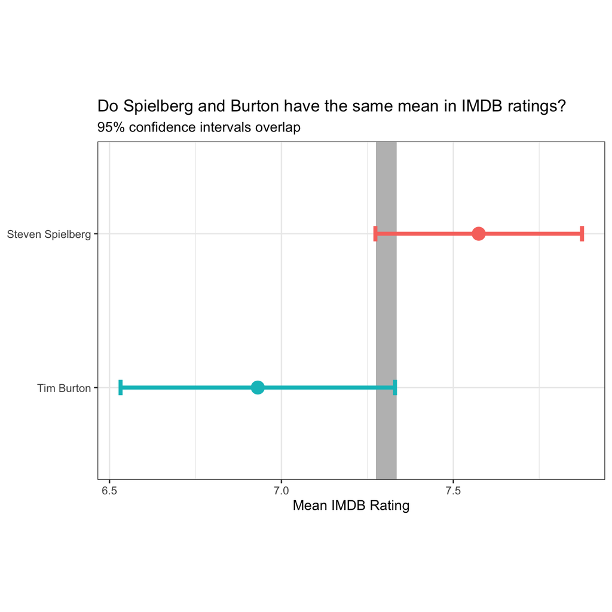

```r
ggplot(Steve_vs_Tim, aes(x=reorder(director, mean_rating))) +
  geom_point(aes(y=mean_rating, color=director, size=4)) +
  geom_rect(aes(xmin=-Inf,xmax=+Inf,ymin=7.275,ymax=7.335),fill="grey",alpha=1)+
  geom_errorbar(aes(ymin=lower, ymax=upper, color=director), width=0.1, size=1.5) +
  coord_flip() +
  labs (
    title = "Do Spielberg and Burton have the same mean in IMDB ratings?",
    y = "Mean IMDB Rating",
    subtitle = "95% confidence intervals overlap"
  ) +
  theme_bw() +
  theme(axis.title.y = element_blank(),
        aspect.ratio = 1/1.5) +
  theme(legend.position = "none")
```

As you can see, there is some overlap in rating between films by Steven Spielberg and by Tim Burton, although not too much, at the 95% confidence interval. Ratings for Spielberg tend to be considerably higher than Burton.